# PCA_JUNG

Chloe Jung

January 21, 2021

#### Import Files

```r
library(haven)
fatality <- read_sav("fatality.sav")
fatality
```

```
## # A tibble: 50 x 7
##    state frate drink gasuse drivers density  temp
##    <chr> <dbl> <dbl>  <dbl>   <dbl>   <dbl> <dbl>
##  1 AL      4.2    19    2.4     2.2      68    40
##  2 AK      4.7    19    0.2     0.2       1    18
##  3 AZ      5.3    19    1.6     1.5      16    38
##  4 AR      3.6    21    1.5     1.4      37    29
##  5 CA      3.4    21   12.6    15.1     128    47
##  6 CO      3.5    21    1.6     2        21    16
##  7 CT      2.3    18    1.5     1.9     624    22
##  8 DE      3.3    20    0.3     0.4     277    24
##  9 FL      3.2    18    5       6.8     125    45
## 10 GA      3.3    18    3.5     3.4      79    33
## # ... with 40 more rows
```

```r
features <- c("state", "frate", "drink", "gasuse", "drivers", "density", "temp")
```

Features: - state: name of state - frate: fatalities per 100M vehicle miles driven - drink: min drinking age - gasuse: gasoline use - drivers: total number of drivers (M) - density: population density - temp: mean January daytime low temp

“State” will be excluded

```r
# If "state" were to be included, must be converted into numeric
#fatality$state = as.numeric(as.factor(fatality$state))
```

### PCA Using “prcomp”

prcomp: The calculation is done by a singular value decomposition of the (centered and possibly scaled) data matrix, not by using eigen on the covariance matrix. This is generally the preferred method for numerical accuracy.

```r
fatality.pca <- prcomp(fatality[2:7], center = TRUE, scale = TRUE)
summary(fatality.pca)
```

```
## Importance of components:
##                           PC1    PC2    PC3    PC4     PC5     PC6
## Standard deviation     1.5262 1.2474 1.0719 0.7968 0.55677 0.14425
## Proportion of Variance 0.3882 0.2593 0.1915 0.1058 0.05167 0.00347
## Cumulative Proportion  0.3882 0.6475 0.8390 0.9449 0.99653 1.00000
```

### Scree Plot and Cumulative Variance Plot

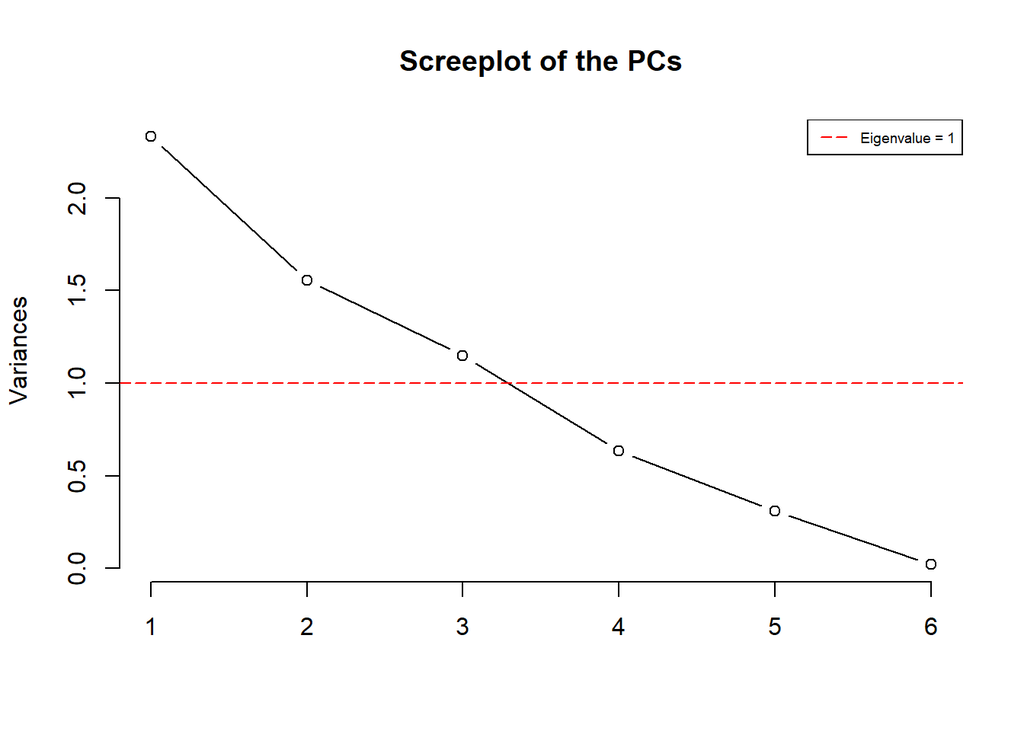

```r
screeplot(fatality.pca, type = "l", main = "Screeplot of the PCs")
abline(h = 1, col="red", lty=5)
legend("topright", legend=c("Eigenvalue = 1"),
       col=c("red"), lty=5, cex=0.6)
```

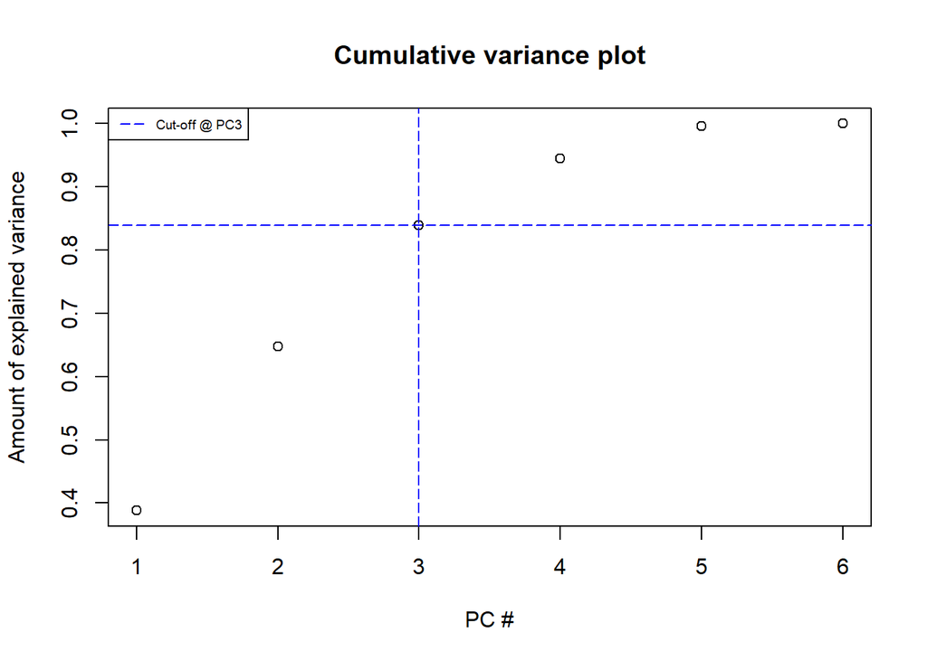

```r
# Cumulative Variance Plot
cumpro <- cumsum(fatality.pca$sdev^2 / sum(fatality.pca$sdev^2))
plot(cumpro[], xlab = "PC #", ylab = "Amount of explained variance", main = "Cumulative variance plot")
abline(v = 3, col="blue", lty=5)
abline(h =  0.8390, col="blue", lty=5)
legend("topleft", legend=c("Cut-off @ PC3"),
       col=c("blue"), lty=5, cex=0.6)
```

### Explanation for Scree Plot and Cumulative Variance Plot

An eigenvalues < 1 means that component explains less than a single explanatory variable, and therfore, PCs that have eigenvalues less than 1 can be discarded.

Including PC1, PC2, and PC3 accounts for around 83.9% of the cumulative variance, which seems to be good.

### Plot PC1 and PC2

```r
library(ggfortify)
```

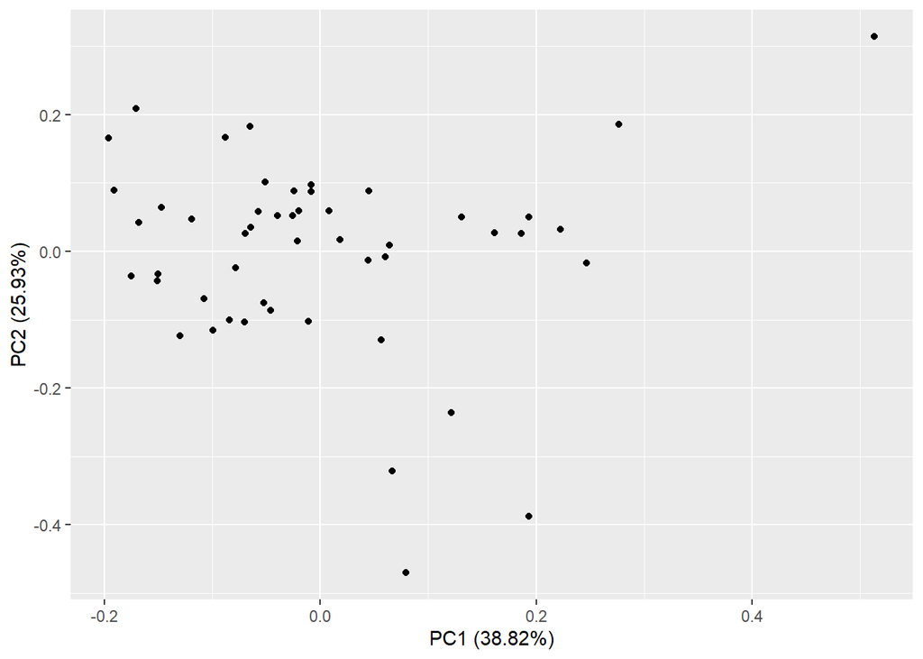

```r
pca.plot <- autoplot(fatality.pca, data = fatality, color = 'state')
pca.plot
```

### Dotplot

```r
# Dotplot for PC1
load <- fatality.pca$rotation
sorted.loadings <- load[order(load[, 1]), 1]
sorted.loadings
```

```
##       frate       drink        temp     density      gasuse     drivers
## -0.31082403 -0.04445799  0.28684181  0.30559172  0.59949214  0.60527396
```

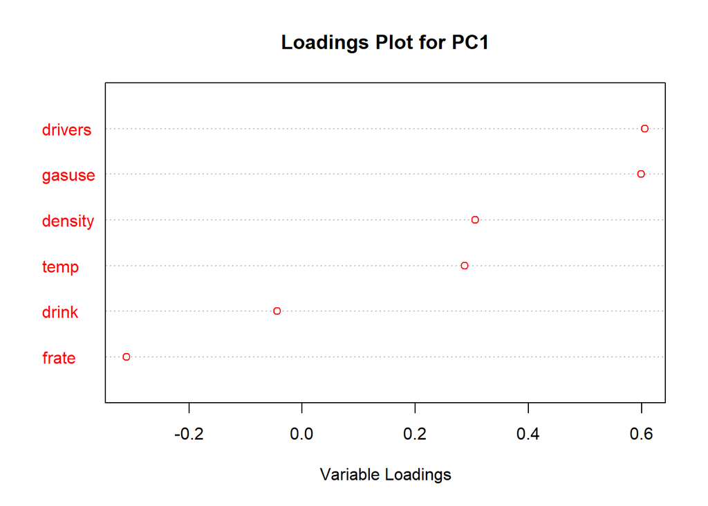

```r
dotchart(sorted.loadings, main="Loadings Plot for PC1", xlab="Variable Loadings", cex=1, col="red")
```

```r
# Dotplot for PC2
load <- fatality.pca$rotation
sorted.loadings <- load[order(load[, 2]), 2]
sorted.loadings
```

```
##    density    drivers     gasuse      drink       temp      frate
## -0.6020724  0.2219819  0.2551240  0.3078128  0.3113693  0.5757127
```

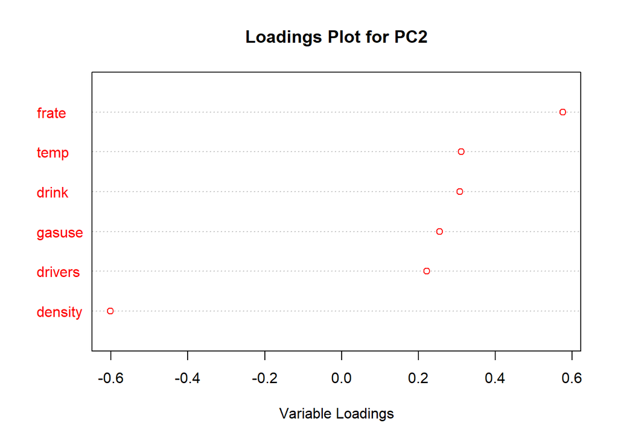

```r
dotchart(sorted.loadings, main="Loadings Plot for PC2", xlab="Variable Loadings", cex=1, col="red")
```

### Biplot

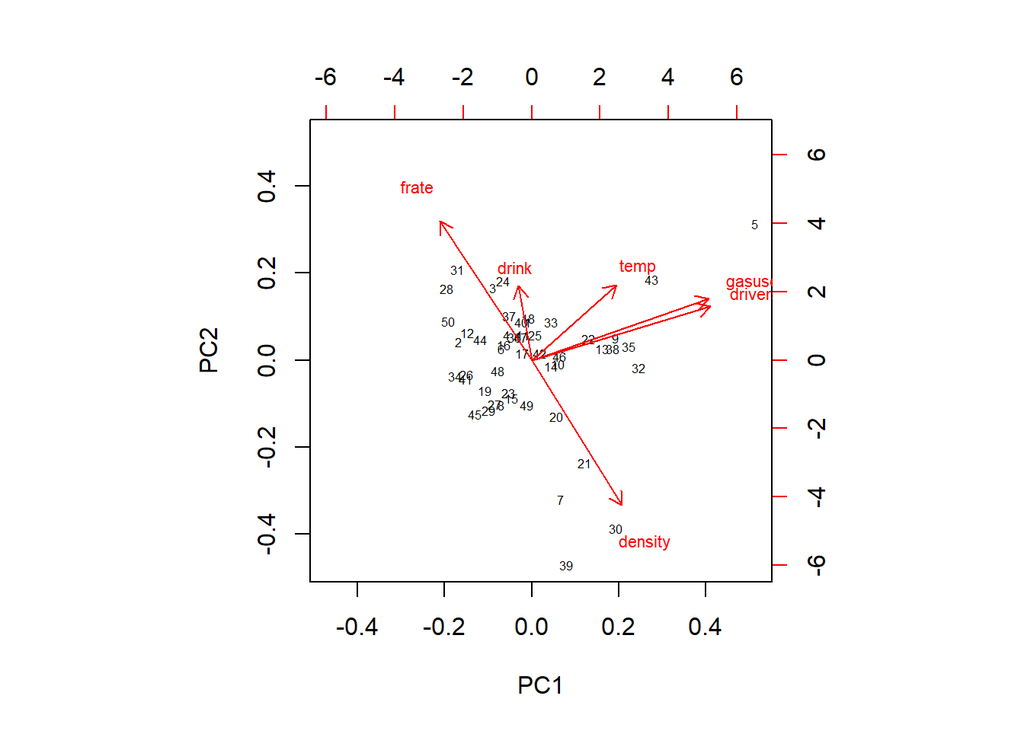

```r
biplot(fatality.pca, cex=c(0.5, 0.7))
```

#### Varimax

- change of coordinates that maximizes the sum of variances of the squared loadings
- goal to clean up the rotation

```r
fatality.var = varimax(fatality.pca$rotation)
fatality.var
```

```
## $loadings
##
## Loadings:
##         PC1 PC2 PC3 PC4 PC5 PC6
## frate                    1
## drink            1
## gasuse                      -1
## drivers  1
## density     -1
## temp                -1
##
##                  PC1   PC2   PC3   PC4   PC5   PC6
## SS loadings    1.000 1.000 1.000 1.000 1.000 1.000
## Proportion Var 0.167 0.167 0.167 0.167 0.167 0.167
## Cumulative Var 0.167 0.333 0.500 0.667 0.833 1.000
##
## $rotmat
##           [,1]        [,2]        [,3]       [,4]         [,5]        [,6]
## [1,] 0.6052485 -0.30559292 -0.04445852 -0.2868426 -0.310825525 -0.59951604
## [2,] 0.2219731  0.60207047  0.30781290 -0.3113701  0.575713317 -0.25513355
## [3,] 0.1255689  0.11925615  0.73863462  0.5659708 -0.306554820 -0.10065042
## [4,] 0.2421875  0.34343003 -0.58251732  0.6434204  0.097906205 -0.24596581
## [5,] 0.1174902 -0.64056944  0.13492955  0.2928510  0.684341902 -0.05979424
## [6,] 0.7043976  0.04035715 -0.01269418 -0.0263728 -0.007506494  0.70801296
```

## Alternative Method

### PCA Using “princomp” on Correlation Matrix

### Convert to correlation matrix

```r
# Correlation matrix
fatality.cor = cor(fatality[2:7])
fatality.cor = as.matrix(fatality.cor)
fatality.cor
```

```
##               frate       drink      gasuse     drivers     density        temp
## frate    1.00000000  0.04015887 -0.21287487 -0.24374237 -0.60401652  0.16847681
## drink    0.04015887  1.00000000  0.05725491  0.06537006 -0.26740559 -0.13523471
## gasuse  -0.21287487  0.05725491  1.00000000  0.97747469  0.13278484  0.35241361
## drivers -0.24374237  0.06537006  0.97747469  1.00000000  0.17562387  0.32108180
## density -0.60401652 -0.26740559  0.13278484  0.17562387  1.00000000  0.07216059
## temp     0.16847681 -0.13523471  0.35241361  0.32108180  0.07216059  1.00000000
```

### PCA and Scree Plot

```r
# PCA
fatality.pca2 <- princomp(fatality[2:7], cor = TRUE, scores = TRUE, covmat = fatality.cor)
print(fatality.pca2)    ## prints out eigenvalues
```

```
## Call:
## princomp(x = fatality[2:7], cor = TRUE, scores = TRUE, covmat = fatality.cor)
##
## Standard deviations:
##    Comp.1    Comp.2    Comp.3    Comp.4    Comp.5    Comp.6
## 1.5262160 1.2473760 1.0719345 0.7967875 0.5567733 0.1442474
##
##  6  variables and  NA observations.
```

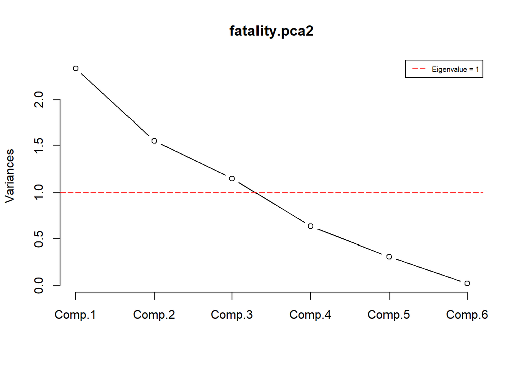

```r
# Scree Plot
plot(fatality.pca2,type='l')   ## scree plot
abline(h = 1, col="red", lty=5)
legend("topright", legend=c("Eigenvalue = 1"),
       col=c("red"), lty=5, cex=0.6)
```

The scree plot seems to suggest the same result as seen when used “prcomp,” which is expected.

### Plot PC1 and PC2

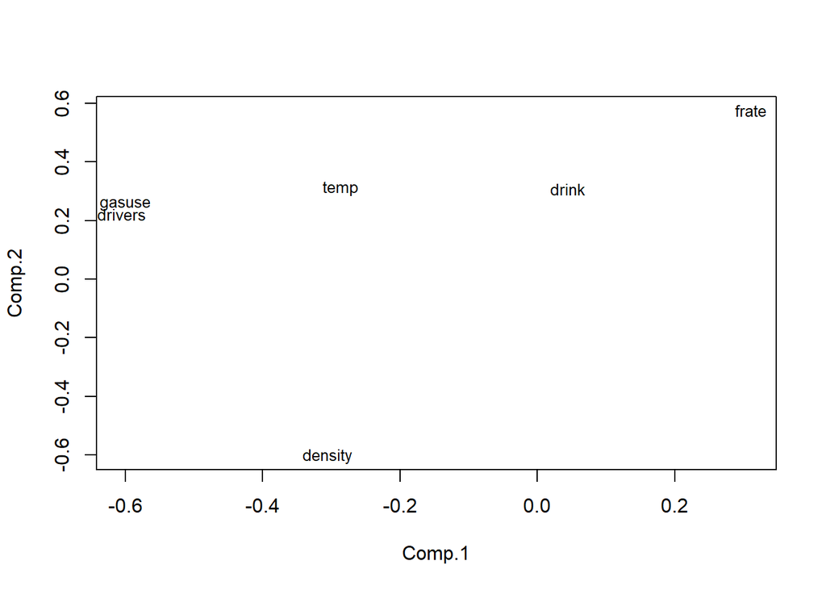

```r
# Plot of first two components
P12<-fatality.pca2$loadings[,1:2]  ## prepare to plot the first two components, with full variable names
plot(P12,pch=' ')  # plot components with blanks at first
text(P12, rownames(fatality.cor), cex=0.8)  # then add full subtest names
```

### Eigendecomposition

- use “eigen” directly, and define the principal components in terms of the eigendecomposition
- accomplish a PCA via the eigendecomposition routines in R function eigen returns eigenvalues (in $values) and eigenvectors (in $vectors)

```r
fatality.eigen<-eigen(fatality.cor,symmetric=TRUE)
fatality.eigen
```

```
## eigen() decomposition
## $values
## [1] 2.32933531 1.55594699 1.14904355 0.63487027 0.30999656 0.02080732
##
## $vectors
##             [,1]       [,2]       [,3]        [,4]        [,5]         [,6]
## [1,]  0.31082403  0.5757127  0.3065545  0.09790571  0.68434333 -0.007505911
## [2,]  0.04445799  0.3078128 -0.7386347 -0.58251731  0.13492932 -0.012693945
## [3,] -0.59949214  0.2551240 -0.1006450  0.24595550  0.05978973 -0.708041381
## [4,] -0.60527396  0.2219819 -0.1255721  0.24219617  0.11749243  0.704368997
## [5,] -0.30559172 -0.6020724  0.1192556 -0.34343046  0.64056806 -0.040357748
## [6,] -0.28684181  0.3113693  0.5659712 -0.64342092 -0.29285075  0.026372238
```

```r
fatality.eigen$values
```

```
## [1] 2.32933531 1.55594699 1.14904355 0.63487027 0.30999656 0.02080732
```

```r
fatality.eigen$vectors
```

```
##             [,1]       [,2]       [,3]        [,4]        [,5]         [,6]
## [1,]  0.31082403  0.5757127  0.3065545  0.09790571  0.68434333 -0.007505911
## [2,]  0.04445799  0.3078128 -0.7386347 -0.58251731  0.13492932 -0.012693945
## [3,] -0.59949214  0.2551240 -0.1006450  0.24595550  0.05978973 -0.708041381
## [4,] -0.60527396  0.2219819 -0.1255721  0.24219617  0.11749243  0.704368997
## [5,] -0.30559172 -0.6020724  0.1192556 -0.34343046  0.64056806 -0.040357748
## [6,] -0.28684181  0.3113693  0.5659712 -0.64342092 -0.29285075  0.026372238
```

# Compuing Principal Components from Eigenvectors & Eigenvalues

```r
# prepare to compute principal components from eigenvectors & eigenvalues

# 1. create 2x2 diagonal identity matrix
I2<-matrix(c(1,0,0,1),nrow=2,byrow=TRUE)

# 2. plug sqrt(eigenvalues) into diagonal of identity matrix to create weighting matrix "wgt"
wgt<-I2
for (i in 1:2) {wgt[i,i]<-(fatality.eigen$values[i])^.5}
print(wgt)
```

```
##          [,1]     [,2]
## [1,] 1.526216 0.000000
## [2,] 0.000000 1.247376
```

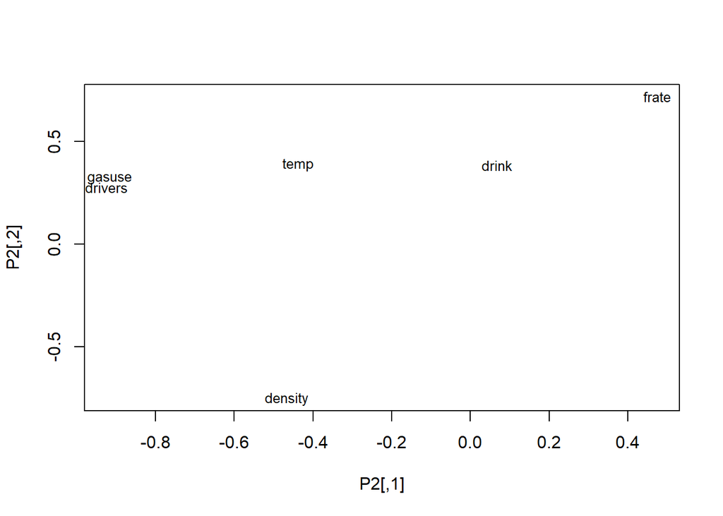

```r
# 3. weight the first two eigenvectors to obtain (the first 2) principal components
P2<-fatality.eigen$vectors[,1:2] %*% wgt

# 4. plot the first two principal components
rownames(P2)<-rownames(fatality.cor)
plot(P2,pch=' ')
text(P2,rownames(P2),cex=0.8)  # add full variable names
```

### Varimax

```r
# most common method for orthogonal analytic rotation: VARIMAX
vmax<-varimax(P2,normalize=TRUE,eps=1e-5)
P2_vmax<-vmax$loadings
P2_vmax
```

```
##
## Loadings:
##         [,1]   [,2]
## frate    0.119  0.852
## drink   -0.104  0.376
## gasuse  -0.963 -0.106
## drivers -0.953 -0.147
## density        -0.879
## temp    -0.562  0.162
##
##                 [,1]  [,2]
## SS loadings    2.186 1.699
## Proportion Var 0.364 0.283
## Cumulative Var 0.364 0.648
```

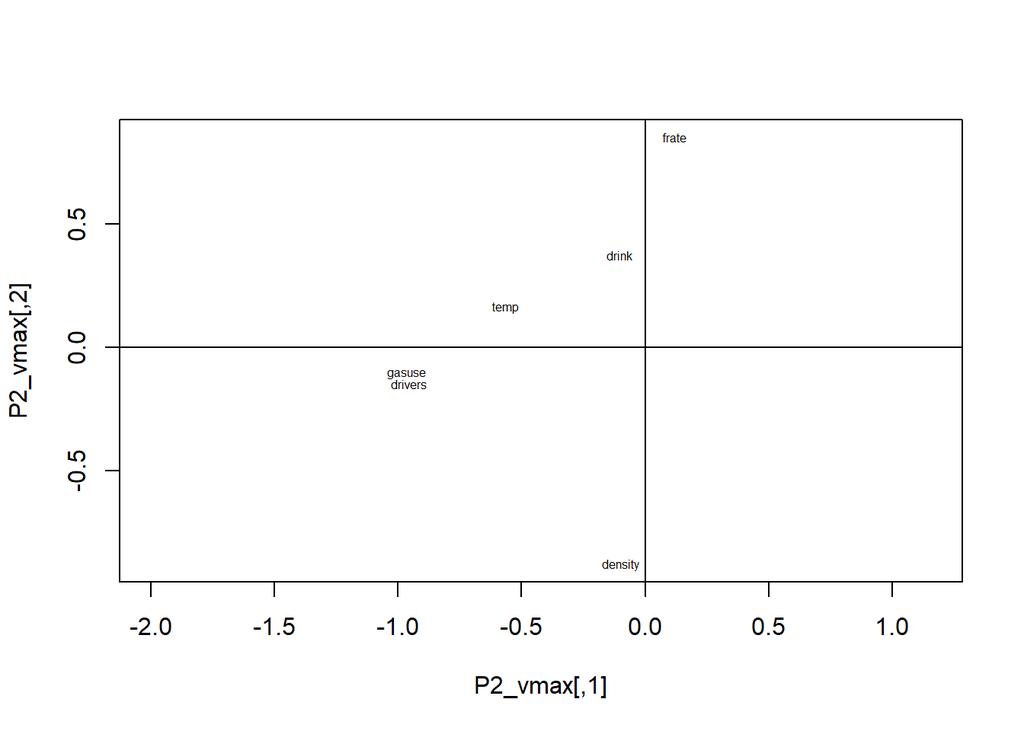

```r
plot(P2_vmax,pch=' ',asp=1,)
abline(h = 0, v = 0)
text(P2_vmax,rownames(P2),asp=1, cex=0.5)  # add full variable names
```

### Interpretation from the analysis above

fatality rate (frate) and population density (density) seem to have contrasting relationship, while the gas use (gasuse) and number of drivers (driver) seem to have a close relationship.

States 30, 39, 21, 7 seem to have contrasting relationship with states 31, 28, 24.